# The Many Uses of pdx_Trees

### Here are some examples of the different ways `pdxTrees` can be used in the classroom setting!

Loading the required libraries.

```r
library(pdxTrees)
library(tidyverse)
```

## A histogram with `ggplot2`

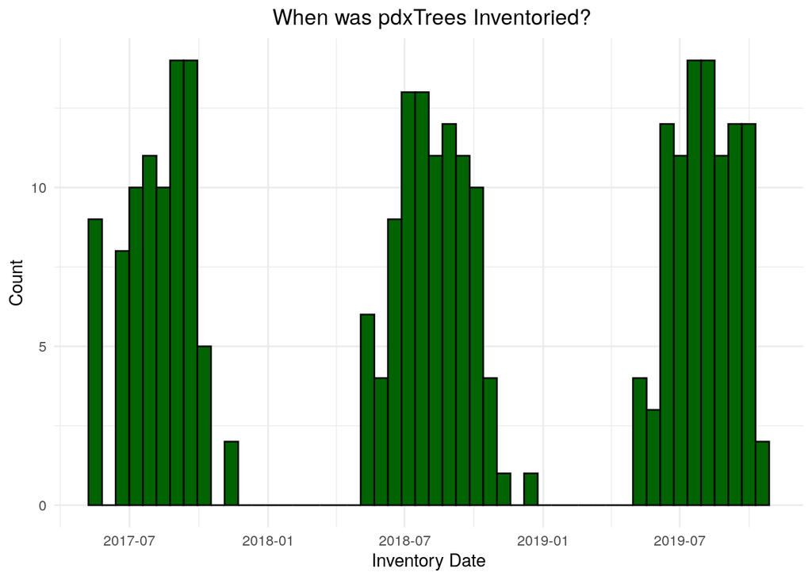

```r
# a histogram of the inventory date
pdxTrees_parks %>%
  count(Inventory_Date) %>%
  # setting the aesthetics
  ggplot(aes(x = Inventory_Date)) +
  # specifying a histogram and picking color!
  geom_histogram(bins = 50,
                 fill = "darkgreen",
                 color = "black") +
  labs( x = "Inventory Date",
        y = "Count",
        title= " When was pdxTrees Inventoried?") +
  # adding a theme
  theme_minimal() +
  theme(plot.title = element_text(hjust = 0.5))
```

Using `ggplot2` we can create a histogram of the `pdxTrees_parks` inventory dates. The trees were inventoried from 2017 to 2019 with the majority of the trees inventoried in the summer months, when the weather is nice in Portland.

This graph is only one of example of how `pdxTrees` can be used to create data visulizations. Once you get the basics of `ggplot2` down you can add animation with `gganimate` or create an interactive map with `leaflet`. Aside from visulizations, the data can also be used to run linear regressions, create confidence intervals, and perform many other forms of statistical inference.

## A Linear Regression

```r
# moderndive is where the lm() function lives
library(moderndive)
```

```r
# running a linear regression of tree_height on stormwater_Ft
mod <- lm(Pollution_Removal_value ~ Tree_Height, data = pdxTrees_parks)

# Coefficients table
get_regression_table(mod) %>%
  print.data.frame()
```

```
##          term estimate std_error statistic p_value lower_ci upper_ci
## 1   intercept    1.306     0.071    18.499       0    1.167    1.444
## 2 Tree_Height    0.104     0.001   113.987       0    0.102    0.106
```

### Interpreting the Regression Table

Looking at the coefficients from the regression table it does seem like tree height has an affect on pollution removal. An intercept term of $\hat\beta_0 = 1.306$, means when the tree_height equals zero the `pollution_removal_value` is 1.306. Obviosuly you wouldn't have a tree that is zero feet tall, but this represents the y-intercept if we graph the regression. $\hat\beta_1 = 0.104$ implies that when the `tree_height` increases by one ft. the `pollution_removal_value` increases by 0.104. The $ _1 $ coefficent represents our slope. The null hypothesis is tree height has no affect on pollution removal and then alternative hypothesis is tree height has an affect on pollution removal. With a p-value of zero we can reject the null hypothesis at a 1% significance level and support the alternative hypothesis that tree height does have an affect on pollution removal. We can visualize this relationship by plotting the data below with `ggplot2`.

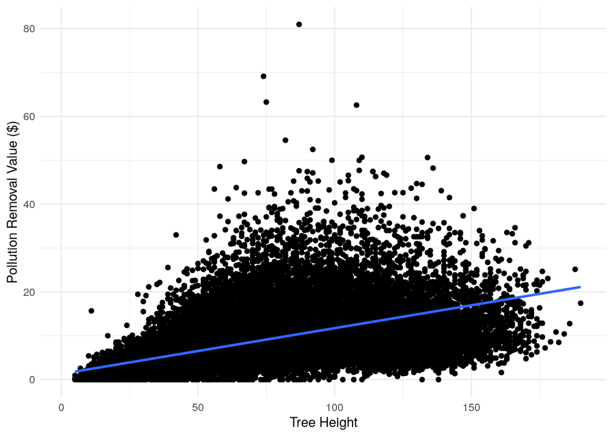

```r
# visualizing the relationship between the two variables.

ggplot(pdxTrees_parks, aes(x = Tree_Height, y = Pollution_Removal_value )) +
 # creating a scatterplot
  geom_point() +
 # adding the line of best fit
  stat_smooth(method = lm, se = FALSE) +
  theme_minimal() +
  labs(x = "Tree Height",
       y = "Pollution Removal Value ($)")
```

Now we can use the `infer` package along with `pdxTrees` to find the correlation coefficient between `tree_height` and `pollution_removal_value`.

### A Correlation Coefficient

```r
# loading infer
library(infer)
```

```r
# the correlation coefficient
pdxTrees_parks %>%
  drop_na(Tree_Height) %>%
  drop_na(Pollution_Removal_value) %>%
  summarise(cor = cor(Tree_Height, Pollution_Removal_value))
```

```
##         cor
## 1 0.5811187
```

The correlation coefficient is $\rho$ = 0.58. This means that `pollution_removal_value` and `tree_height` have a moderate positive correlation. A correlation coefficient ranges from -1 to 1, with -1 being a strong negative correlation, 1 being a strong postive correlation, and zero indicating no correlation. We can also use `pdxTrees` to create a confidence interval for the correlation coefficient using the bootstrap method.

### A Confidence Interval

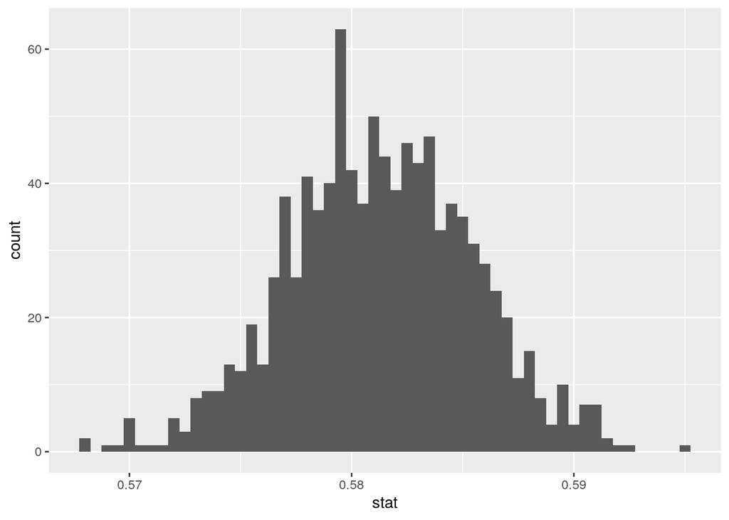

```r
# creating the bootstrap distribution
bootstrap_trees <- pdxTrees_parks %>%
  # dropping NA's
  drop_na(Tree_Height) %>%
  drop_na(Pollution_Removal_value) %>%
  # the variables of interest
  specify(Tree_Height ~ Pollution_Removal_value) %>%
  # performing 1000 reps of the bootstrap sampling
  generate(reps = 1000, type = "bootstrap") %>%
  # specifying a correlation statistic
  calculate(stat = "correlation")

# plotting bootstrap distribution
ggplot(bootstrap_trees, aes(x = stat)) + # statistic defined above
  geom_histogram(binwidth = 0.0005)
```

```r
# creating a 95% confidence interval
ci_95 <- bootstrap_trees %>%
      # level = the size of confidence interval you want
  get_confidence_interval(type = "percentile", level = 0.95)

ci_95
```

```
## # A tibble: 1 x 2
##   `2.5%` `97.5%`
##    <dbl>   <dbl>
## 1  0.573   0.590
```

### Intrepreting the results:

I am 95% confident that the correlation coefficient lies between 0.57 and 0.589 This means that `tree_height` and `pollution_removal_value` are moderatly postivly correlated. An increase in `tree_height` results in an increase of `pollution_removal_value`, but it is not a strict one to one relationship. Visually we can see that our bootstrap distribution is bellshaped, symmmetric, and centered around the correlation coefficient. Even if our coefficent is the lower bound of our confidence interval there is still a moderate positive correlation.

## An interactive map with `Leaflet`

The following code runs through the process of creating an interactive map with `Leaflet` and the `pdxTrees` data. It includes adding popups for each tree where you can customize the information displayed on the popup and the icon that represents the tree. You can also change the background map and add minimaps!

```r
# loading the leaflet packages
library(leaflet)
library(leaflet.extras)
```

```r
# making the leaf popup icon
greenLeaflittle <- makeIcon(
  iconUrl = "http://leafletjs.com/examples/custom-icons/leaf-green.png",
  iconWidth = 10, iconHeight = 20,
  iconAnchorX = 10, iconAnchorY = 10,
  shadowUrl = "http://leafletjs.com/examples/custom-icons/leaf-shadow.png",
  shadowWidth = 10, shadowHeight = 15,
  shadowAnchorX = 5, shadowAnchorY = 5
)


# filtering using dplyr to just Berkeley Park

berkeley_prk <- pdxTrees_parks %>%
  filter(Park == "Berkeley Park")


# creating the popup label

labels <- paste("</b>", "Common Name:",
                 berkeley_prk$common_name,
                 "</b></br>", "Factoid: ",
              berkeley_prk$species_factoid)


# creating the map

leaflet() %>%
  # setting the lng and lat to be in the general area of Berekely Park
 setView(lng = -122.6239, lat = 45.4726, zoom = 17) %>%
  # setting the background tiles
  addProviderTiles(providers$Esri.WorldTopoMap) %>%

  # adding circle markers to shade where the tree is located
  addCircleMarkers(lng = ~Longitude, lat = ~Latitude,
             data = berkeley_prk,
             radius = 2, fillOpacity = 0.9,
             color = "darkblue") %>%
  # adding the leaf markers with the popup data on top of the circles markers
  addMarkers( ~Longitude, ~Latitude,
              icon = greenLeaflittle,
              data = berkeley_prk,
              popup = labels) %>%
  # adding the mini map at the bottom right corner
  addMiniMap()
```

[interactive chart not shown]

## Creating an animated graph using `gganimate`

```r
library(gganimate)
```

### Before you animate a graph with `gganimate` you have to create a graph with `ggplot2` and save it as an object.

```r
# refactoring the categorical mature_size variable
berkeley_prk <- berkeley_prk %>%
 mutate(mature_size = fct_relevel(Mature_Size, "S", "M", "L"))


# first creating the graph using ggplot and saving it!
berkeley_graph <- berkeley_prk %>%
  # piping in the data
                  ggplot( aes(x = Tree_Height,
                              y = Pollution_Removal_value,
                              color = Mature_Size)) +
  # creating the scatterplot
                  geom_point(size =3  ) +
                  theme_minimal() +
  # adding the labels
                  labs(title = "Pollution Removal Value of
                       Berkeley Park Trees",
                       x = "Tree Height",
                       y = "Pollution Removal Value ($'s anually)",
                       color = "Mature Size") +
  # adding a color palette
                  scale_color_brewer(type = "seq", palette = "Set1") +
  # customizing the title font
                  theme(plot.title = element_text(hjust = 0.5,
                                                  size = 18,
                                                  face = "bold"))
```

#### Now we can add animation!

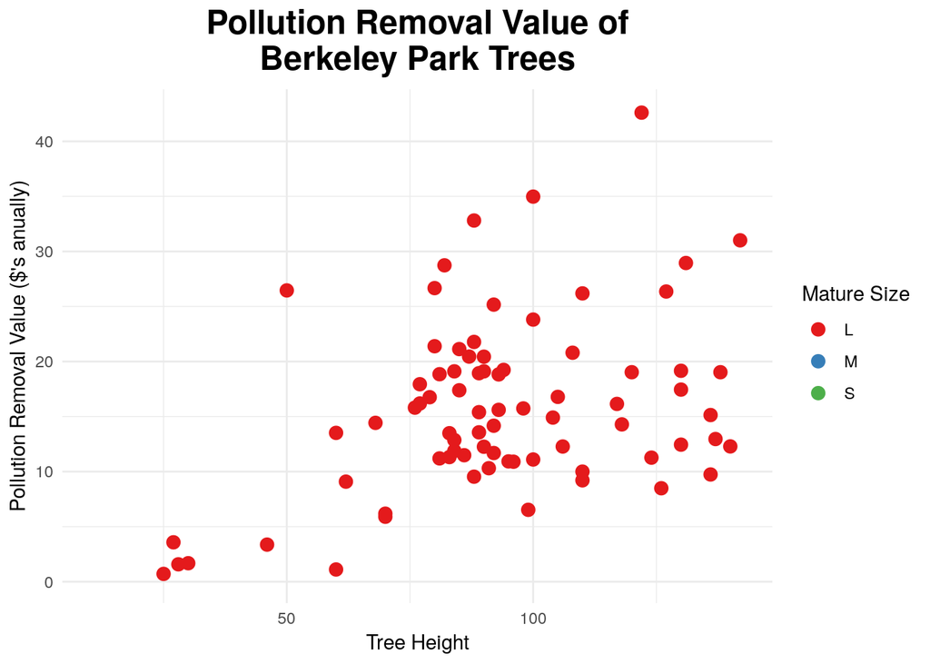

```r
# then adding the animation with gganimate functions
berkeley_graph +
  # chosing which variable we want to annimate
  transition_states(states = Mature_Size,
                    #how long each point stays before fading away
                    transition_length = 10,
                    #the time the transition takes
                    state_length = 8)  +
  #annimation for the points entering
  enter_grow() +
  #annimation for the points exiting
  exit_shrink()
```

Unsurprisingly it seems that large have the highest `Pollution_Eemoval_value`, but it does seem there is a lot of overlap between the height categories.